# The Viridian Project: A digital currency to internalize external costs for a more sustainable economy

Markus Voge

December 9, 2017

# Introduction

Among the biggest problems of humanity in the 21st century areenvironmental crises such as global warming, but also social crises such as inequal distribution of wealth, with some still suffering from hunger. These problems in turn are catalysts for conflicts and migration, putting entire societies under stress. Many experts say that we are pushing the Earth’s systems beyond their planetary boundaries [1,15], and that the current lifestyle of the Global North would require more than one planet to survive in the long term.[^1]

Most of these problems have to do with economic activity and the underlying monetary systems [11]. One well-known problem is the privatization of profits, while costs, e.g. of environmental damages, are being socialized [20,21]. As a result, often small elites are becoming wealthier, while a majority’s well-being is stagnating or even declining. Another result is the acceptance (also by the suffering majority) of environmental damage as an inevitable consequence of economic activity and progress, even when it is risking to destroy the very foundation of life and when healthier alternatives are both available and financeable by society [10]. One problem of established monetary systems is the inevitability of unlimited economic growth, which is, as many have pointed out [6,8,12,16], opposed to the fact of living on a planet with limited resources. The economic growth is largely driven by the financial sector and the habit of paying interest rate and return of investment: companies acquiring money are forced to grow to reel in more than they invested and pay back their donors. For instance, this drives fossil fuel companies to ever riskier extraction practices, such as fracking, deep sea drilling, or drilling in the Arctic, with sometimes catastrophic consequences [10].

# Changing the monetary system

As turned out by Belgian economist Bernard Lietaer [11], all of these problems might be addressed by monetary innovations. One interesting idea is the concept of complementary currencies: Currencies that have limited validity, e.g. only in a certain geographic area or only within certain branches of economy. These currencies are not to replace national or international currencies, but to complement them and thereby strengthen closed circles and reduce extreme aggregation of wealth. The idea of complementary currencies is already actively followed by people from several groups, e.g. the Transition Towns movement [8] that aims to build a post-fossil, sustainable, and resilient economy and by the degrowth movement [3,4,9] that aims to put an end to unlimited economic growth. Complementary currencies are already in use at some places and prove to strengthen regional and more sustainable value generation. In addition, there are more ideas to redesign our monetary systems, e.g. *The Chicago Plan Revisited* [2,22], a report issued by the International Monetary Fund (IMF) in 2012, suggesting that private banks should only be allowed to lend money that they have in deposits (100% reserve banking), reducing both public and private debt and resulting in a more balanced and stable economy. Another idea is to establish a complementary currency on the national level in each country, distributed to all citizens as a basic income, thereby “insulat[ing] local sustainability and resilience from the deleterious effects of globalization and financial speculation” [9].

Another monetary innovation are cryptocurrencies (the most popular being Bitcoin) based on a distributed ledger or blockchain, which do not require any kind of central institution like a bank [13]. Besides the benefit of reduced cost, a much more fascinating aspect of cryptocurrencies is that of the democratization of money. Instead of restricting the privileges of the creation of new money and the verification of money transactions to few centralized (mostly private) banks, giving them a great deal of power, this power is distributed by giving it to a large group of relatively equal players, which everyone can join. A downside is that cryptocurrencies can only exist digitally and thus require the use of electronic devices. This creates a vulnerable dependency on electricity and might increase resource consumption,[^2] which is not good from a sustainability perspective. On the other hand, smartphone devices capable of digital payments are already now almost ubiquitous, even in developing parts of the world.

Cryptocurrencies are not controlled by central institutions, banks and/or governments, i.e. individual people, but by mathematic algorithms carried out by computer software, distributed on all participants’ devices. This offers several opportunities: In principle, these algorithms can be formulated in any imaginable way, enabling the easy implementation of a very different monetary system. Also, if designed properly, it might be much harder to break the rules of the currency system, since computers, unlike people, are not corruptible. Especially if manipulation on a majority of devices would be necessary, then this is virtually impossible, which is also what makes Bitcoin a very secure currency.

## A new ethical cryptocurrency

The idea is to combine the aim of a more sustainable economy with the benefits of cryptocurrencies. If cryptocurrencies can be designed as one sees fit, then it might be possible to solve the problems of conventional monetary systems.

As a starting point, one can try to incorporate external costs into prices of products and services. External costs are those that are not part of the economic calculation when a price is determined, however they still arise (sometimes at a different place and/or time, harming third parties) and have to be paid by someone, usually the tax payer or residents of affected areas. Examples of external costs are health damages caused by pollution or costs of disasters that are the result of careless extraction of resources, including more frequent extreme weather events as a result of green house gas emissions. In order to ensure that external costs are taken care of as well as discourage harmful and encourage sustainable behavior, it is better to internalize external costs into the actual price.

## Two-dimensional money

The problem is that a (traditional) currency system cannot directly influence the way a business owner determines prices. The currency as a whole can be valued up or down by increasing or reducing the amount of fresh money (i.e. setting the key interest rate), but that does not influence individual trades. However, cryptocurrencies basically consist of transactions between peers and may offer a possibility to interfere right there. A possible idea is to add another dimension to money.

Ever since the invention of money, it has been one-dimensional in its very nature, the single dimension being value, or rather quantity. Money is a single scale, against which almost every thing can be measured. Digital currencies might remove this restriction and could add other dimensions to quantity, for example quality. Not only the mere amount of (physical) wealth would matter, but also the change in quality of life that comes along with the aggregation of wealth.

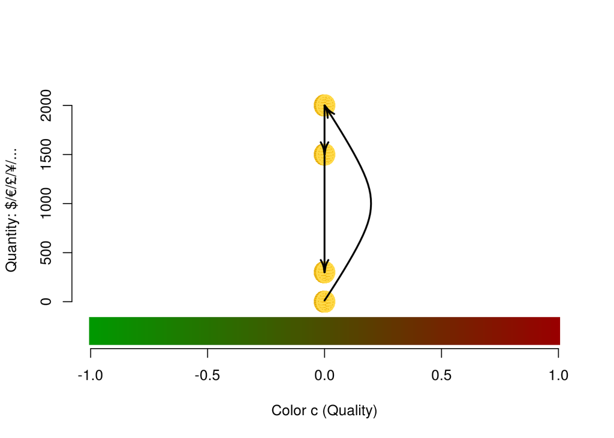

[figure not shown]

Icons made by [Smashicons](https://www.flaticon.com/authors/smashicons) from [www.flaticon.com](https://www.flaticon.com/) is licensed by [CC 3.0 BY](http://creativecommons.org/licenses/by/3.0/)

$$y = (1 + c) \; p$$

It is also an interesting question whether there should be more up or more down valuation, which would essentially either create or destroy money, or whether they should balance each other. This could be controlled via a regularly changing overall normalization of the re-evaluation, so that the average change in the total amount of money is constant. Currently in use mainstream currencies constantly create new money via credits, which creates a low inflation rate. Bitcoin on the other hand, the most prominent cryptocurrency, has a fixed volume of 21 million bitcoins. This limited amount of money leads to a deflationary currency. Mainstream economists argue that it is beneficial to have a low inflation rate, because it prevents people hoarding money and creates an incentive to spend the money and bring it back into circulation. This might lead to a more equal distribution of wealth. On the other hand, it might lead to unnecessary consumption of goods and thus be a driver to (excess) economic growth. Degrowth economists therefore might favor a deflationary currency. There are claims that interest rate (and therefore inflation) incentivizes short-term investments, while an interest-free currency system with demurrage (money losing some if its value over time, i.e. negative interest rate, or money “disappearing”) incentivizes long-term thinking and promotes a more sustainable economy [11].

### An example

As a concrete example for a transaction in the new currency, buying an emission-intensive car with a fossil fuel burning engine might involve red money, while an emission-free electric vehicle is bought with green money.

Upon entering the seller’s wallet, the red money loses some of its value, while the green money is valued up. This effectively means that the fossil fuel car will be sold with a higher price (since the seller gains less), while the electric car gets cheaper. It is like a higher tax on one, while subsidizing the other. The buyer does not even need to know about the color of the transaction or the process of (de-)valuation, only the seller needs to include the color into their price calculation. This makes it easier to adopt for the consumer. This can help cleaner, emerging technologies, sometimes needed as quickly as possible from an ecological point of view, to become marketable much quicker. It can create the right incentives to make good investments and use good practices, while punishing behavior that is harmful to society.

It is important to note that, similar to value added tax, the colorization should probably not be applied multiple times, but only at the end consumer. Intermediate reevaluations must be undone accordingly.

## Redistribution of value

The red money transactions may take a part of the buyer’s money and pay it into a fund to alleviate side-effect damages like environmental disasters or increased health costs and can also fund dedicated projects supporting unemployed people during structural change. This would adhere to the principle of “the polluter pays” [10] and would be considered fair by most people.

All transactions regardless of color should include a small transaction fee that is paid to the color determiners to reward them for their services.

## Managed by the crowd

While a similar effect to that of colored money can be reached by taxation and subsidization, the interesting aspect is that a cryptocurrency offers a possibility to do this without a central authority involved. The main problem of transforming the economy towards sustainable development is to do it in a way that is fair and socially accepted by everyone.

Past policies have failed to do so. The less wealthy will not accept a change that feels like they have to give up their standard of living, while the wealthiest, the ones most responsible, e.g. those profiting from extraction of resources, are not paying their toll. The fear of losing jobs due to a necessary system change is quickly sparked in the public and surely must be addressed, e.g. by dedicated projects. But because governance fails to introduce such projects, which should be paid for by polluters like the fossil fuel companies, system change never comes.

This is why such important decisions like the color of money cannot be placed into the hand of a few privileged, or a single person. It must be done collaboratively by the crowd, in a way that is acceptable by everyone.

This is an attemt to bypass government and any centralized institutions or elites: Like the Bitcoin miners perform the service of validating transactions and keeping the currency’s network secure, dedicated decentralized groups could determine the transaction colors. Much like developers of open source software, there could be groups of people dedicated to auditing certain products or producers in terms of sustainability. Collaboratively, they determine the color in an open and transparent way. There should be an online platform, a “Github of the economy”, where the color determination takes place and is documented. Every interested individual can view how the decision on color was reached and can make suggestions, even though only few have the required experience and the time to actually make decisions.

## The hard problem of finding color

Determining a fair color for virtually every product or service that can be bought seems like such a colossal task that it might well be deemed impossible. It might mean performing audits similar to what is done currently for products to obtain certain labels on sustainability or fair trade, but not for some specific products, but for everything. On the other hand, there already exist software tools and databases for performing lifecycle analyses (LCA), which could be leveraged to estimate products’ environmental impact, an important part of the color determination. Also, if products consist of components, then the color can partly be a composite. If the same components are used in other products, one can re-use their color.

But still, several problems come to mind: One is the question how the transition to the new currency might be done, a classical hen-egg-problem. If the currency is not in wide use, only very few products will have an adequate color. This means only few products can be bought with the new currency in a meaningful way, which might attract few adopters, leading to very limited usage.

Another problem is that of scalability: while it is in principle possible to determine color, it is very hard to do this completely, including every aspect, and for every product. Of course, perfection is impossible to reach, but one should at least take a closer look, which takes time. A lot of manpower is required to do the audits, which might need to include travels and on-site visits. Some might argue that the work of the auditors would be so expensive that it would be hard for society to pay for it. On the other hand, it should be questioned if an ethical and fair economy is worth the price. However, any idea to simplify the color determination process and save (human) resources as much as possible would be very welcome.

A third problem is that of changing time: The color of a product can never be constant, but must continuously adapt and react to changes in the production. This is important, to reward producers when they improve, to create good incentives. But also to prevent fraud where producers change the production shortly after the audit.

A fourth problem is that one must make sure that the system is not corrupted or gamed. Of course, there will be strong motivation to come out “as green as possible”, so producers will “do their best”, both on legal and illegal paths. The transparency of making all color decisions public on a Github-like platform might help, but probably will not be enough. It is clear that the color determiners would be in an easily corruptible position and it might be a good idea to reward them well to make them more independent from “gifts” from the industry.

## Attracting a critical mass

If the general public is ever to embrace this new technology, it is immensely important to make it attractive not only to a few people hat are both tech-savvy and care about the planet.

One strategy could be to create a subculture that identifies with this new technology as part of their lifestyle. To make the connection stronger, one could make use of good design, e.g. a very smart name, a fitting logo and a “cool”-looking user interface. The subculture embracing the new technology could cause the public to talk about this new phenomenon, raising more and more interest. Eventually, the subculture may blend into the mainstream and become part of everyone’s lives.

However, more important than good-looking design will be usability: ease of use on one hand (paying with the app must be as or even more intuitive than writing a text message), and a perceived gain on the other hand. If the new technology can buy you nothing you can buy with your trusted currency already, and if prices are even higher, then the average customer will not use it, no matter how “sustainable” it is. There must be some advantages to using it. For example, if a new economy would be built around it, there might be products (perhaps highly sought-after innovations) that are only sold in the new currency.

Another interesting strategy would be to create a parallel economy for the new currency that has as many closed circles as possible. This is the concept followed by most complementary currencies. Apart from the new currency enabling access to this somewhat “privileged club”, its use might also have economic advantages. If the alternative currency has more value inside these closed circles than the conventional currency of the outside world, then people will choose to use it. Especially in times of financial crises troubling conventional currencies. This is what happened in some experiments like the Wörgl experiment [23] or the Wära experiment [24], for instance.

It is obvious that it is very important to find early adopters not only among buyers, but even more so among sellers: i.e. producers and merchants (and corresponding auditors). Only if one can buy things, buyers can start using it. Naturally, small companies that already today care a lot about sustainability might be the first adopters. Conservative companies that would be forced to change their behavior will only join when they absolutely have to if they want to survive.

### Challenging the *homo oeconomicus*

On a side note, there are more motivations for people’s actions than selfish advantage. Many surveys have shown that, when being asked openly, a vast majority of individuals agrees to support social or environmental issues [10,18]. This is because everyone wants to appear as a “moral”, “good”, and “social” person towards others. One might call this a kind of “social peer pressure”. But this social peer pressure is completely removed from economic activity. Instead, the neoclassical view of economics has taught us that it is a law of nature that every human must act “selfish” in the economy [17]. This leads, in the absence of peer pressure, to the famous “tragedy of the commmons” [25]. However, communication between individuals, applying peer pressure, can solve this tragedy [14]. So, if some kind of peer pressure would be incorporated into economic transactions by means of cryptocurrency algorithms, it might also help to make economic decisions more balanced and less one-dimensional. The colorization of money transactions might be seen as an application of social peer pressure to trade. Because who would openly deny a societal consensus that takes into account social and environmental values, leading to benefits for everyone? If not using the colored currency would make that person appear to be an immoral misanthrope, then there might be a strong socio-psychological incentive to use it. The psychological effect might be strengthened by showing the transaction color to the customer before the transaction is carried out.

# Possible implementation

From a software architecture point of view, there need to be different components to make the currency system work:

1. A distributed lookup table database to store the colors that can be queried during transactions.
2. A collaborative platform, from which the color database can be edited, perhaps similar to Github.
3. The cryptocurrency itself (a distributed ledger storing the transactions), which is relatively easy to implement, for example as a blockchain in a framework like Ethereum.

## The color database or “color blockchain”

The color database gives a unique ID to each product. It is updated frequently and always returns the current color when queried. It may or may not be a blockchain. A blockchain would have added benefits like tamper resistance as well as version control and traceability. If it is a blockchain, then there would be an “account” for every product and the acount’s balance would be the current color value, which can be changed with “color transactions” by the color determiners, with added meta-data on why the color is changed. Perhaps, it makes sense to store not only the resulting color itself, but also “subcolors” for relevant aspects: social sustainability, environmental sustainability, longevity of the product etc. Maybe the color database can incorporate user ratings as well, e.g. rating the usefulness or the quality of the prduct in use.

The separate color blockchain would be managed by the individuals determining colors, the “color miners”. Color mining is a task quite different from the transaction mining, which secures the transaction blockchain. Color mining involves both auditing or LCA work to gather information backing the color value, but also peer reviewing other miners’ “color transactions” before they become a legitimate part of the blockchain. Each color miner registers an account on the transaction blockchain, to which rewards for their work are transferred.

## The collaborative platform

It must be open to anyone. For reading the platform’s content, no registration is necessary. Anyone registering on the platform is becoming a “color miner” who helps in the determination of colors. Like there can be “projects” in Github, there are workspaces for each product and service. One has to make sure that there is only one “genuine” product workspace and that changes to the color of a product are only done by trusted members. For this purpose, one could introduce a user permission system like a “web of trust”, where only high rated members have permission to create new work spaces and assign write permissions of certain workspaces to certain members. The downside is that this makes the system more complicated, increases the threshold to add new products and introduces a hierarchy. Any better ideas are appreciated.

## The cryptocurrency or “transaction blockchain”

Ethereum is a programming framework for smart contracts. Smart contracts are a generalization of cryptocurrencies, where a blockchain can be used for different purposes. Ethereum is completely independent of the most prominent cryptocurrency, bitcoin, and has its own blockchain and its own cryptocurrency called *ether*, which is not used as a currency, but merely as a means of carrying out smart contracts. With smart contracts, computer code can be attached to the blockchain, which is executed by the miners when the transaction is validated. Therefore, it can be made sure that the content of a contract is carried out as intended and this is stored, secure from manipulation, in the blockchain.

# Conclusion

Leveraging the wisdom of crowds and the power of cryptocurrencies, perhaps one can reach a societal consensus towards a world that is more worth living in for everyone, preserving life for future generations, while not giving up modern lifestyles.

These are the requirements that must be fulfilled by the alternative currency:

1. It must feature a significantly more sustainable and/or fair economy.
2. It must be based on societal consensus to be accepted by (almost) everyone.
3. It must be very easy to use.
4. It must be fun to use and/or provide a real advantage.
5. It must be relatively hard to break the rules or abuse the system.

I assume that (1) would be a consequence of all the other points fulfilled, if the currency would be designed similar to what is described above. (2) is the main problem remaining to be solved: how to determine the external costs of goods in a socially acceptable way. The idea to use crowdsourcing was only vaguely described here. More thoughts on this would be greatly appreciated. (5) would only partly be fulfilled by the use of cryptocurrencies, how to secure the crowdsourcing against abuse is another problem to be solved. (3) and (4) have only been merely touched on the surface.

Therefore, we are still at the very beginning, but I hope that something good will evolve out of this.

# References

[1] A.D. Barnosky, E.A. Hadly, J. Bascompte, others, Approaching a state shift in earth’s biosphere, Nature. 486 (2012) 52–58.

[2] J. Benes, M. Kumhof, The chicago plan revisited, International Monetary Fund, 2012.

[3] K. Dittmer, Local currencies for purposive degrowth? A quality check of some proposals for changing money-as-usual, Journal of Cleaner Production. 54 (2013) 3–13.

[4] R. Douthwaite, Degrowth and the supply of money in an energy-scarce world, Ecological Economics. 84 (2012) 187–193.

[5] Ethereum, Introduction to smart contracts, (2017).

[6] N. Georgescu-Roegen, The entropy law and the economic process, Harvard University Press, Cambridge, Massachusetts, 1971.

[7] A. Hern, Bitcoin mining consumes more electricity a year than ireland, The Guardian. (2017).

[8] R. Hopkins, The transition handbook - from oil dependency to local resilience, Uit Cambridge Limited, Cambridge, 2014.

[9] A. Hornborg, How to turn an ocean liner: A proposal for voluntary degrowth by redesigning money for sustainability, justice, and resilience, Journal of Political Ecology. 24 (2017) 623–632.

[10] N. Klein, This changes everything - capitalism vs. the climate, Simon; Schuster, New York, 2014.

[11] B.A. Lietaer, Money and sustainability - the missing link : A report from the club of rome - EU chapter to finance watch and the world business academy, Triarchy Press, 2012.

[12] D.H. Meadows, D.L. Meadows, J. Randers, W.W. Behrens, The limits to growth - a report for the club of rome’s project on the predicament of mankind, Universe Books, New York, 1974.

[13] S. Nakamoto, Bitcoin: A peer-to-peer electronic cash system, (2008).

[14] E. Ostrom, Prize lecture: Beyond markets and states: Polycentric governance of complex economic systems, (2009).

[15] J. Rockström, W. Steffen, K. Noone, others, A safe operating space for humanity, Nature. 461 (2009) 472–475.

[16] F. Schneider, G. Kallis, J. Martinez-Alier, Crisis or opportunity? Economic degrowth for social equity and ecological sustainability. introduction to this special issue, Journal of Cleaner Production. 18 (2010) 511–518.

[17] A. Smith, An inquiry into the nature and causes of the wealth of nations, Edited by Sálvio M. Soares, MetaLibri, 2007, v.1.0s, 1776.

[18] Special Eurobarometer, Attitudes of european citizens towards the environment, European Commission, 2008.

[19] M. Wackernagel, others, Global footprint network 2016 annual report, Global Footprint Network, 426 17th Street, Suite 700, Oakland, CA 94612 USA, 2017.

[20] Wikipedia, Externality — Wikipedia, the free encyclopedia, (2017).

[21] Wikipedia, Lemon socialism — Wikipedia, the free encyclopedia, (2017).

[22] Wikipedia, The Chicago Plan Revisited — Wikipedia, the free encyclopedia, (2017).

[23] Wikipedia, Wörgl — Wikipedia, the free encyclopedia, (2017).

[24] Wikipedia, Wära — Wikipedia, the free encyclopedia, (2017).

[25] Wikipedia, Tragedy of the commons — Wikipedia, the free encyclopedia, (2017).

[^1]: The Global Footprint Network annually calculates the date of the *Earth Overshoot Day*, on which humanity has depleted the amount of natural resources that is regenerated each year, see e.g. the 2016 annual report [19], https://www.footprintnetwork.org/our-work/earth-overshoot-day/, or https://www.overshootday.org/. In 2017, the Earth Overshoot Day fell on 2 August.
[^2]: In addition to increased use of electronic devices for performing payments using cyrpto-wallet apps, an enormous energy and resource consumption can be generated when transactions are verified in a cryptocurrency’s network using so-called *proof-of-work* computations. The Bitcoin protocol is based on proof-of-work and the Bitcoin network’s global energy consumption is assumed to exceed that of many European countries, including Ireland [7]. There are some ideas on how to replace proof-of-work with less resource-intensive concepts, e.g. the *proof-of-stake* used by the Ethereum blockchain.
[^3]: Within the cryptocurrency community, already since 2013 there exists the term “colored coins” (see e.g. http://coloredcoins.org/, https://www.coinprism.com/), which has nothing to do with the concept described here. “Colored coins” are bitcoins carrying certain information. They can be used for example to prove ownership of a certain asset. It is called “colored” because a bitcoin is “marked” to make it distinguishable from all other bitcoins. Since the ownership is linked to a cryptocurrency coin, it can be easily transferred to another acount. This enables the realization of “smart contracts”, where digital or real world assets can be sold securely using a blockchain. Colored coins are similar to Ethereum, however not using a seperate blockchain, but the bitcoin blockchain.